# Assignment 2

James La Fontaine

16/09/2021

## Question 3

### 3a)

The difference in scale between the raw brain and body measurements is too significant to fit a suitable model and to produce a suitable plot to compare their relationship

### 3b)

```r
data(Animals, package = "MASS")

brain = log(Animals$brain)
body = log(Animals$body)

model1 = lm(brain ~ body, data = log(Animals))

summary(model1)
```

```
##
## Call:
## lm(formula = brain ~ body, data = log(Animals))
##
## Residuals:
##     Min      1Q  Median      3Q     Max
## -3.2890 -0.6763  0.3316  0.8646  2.5835
##
## Coefficients:
##             Estimate Std. Error t value Pr(>|t|)
## (Intercept)  2.55490    0.41314   6.184 1.53e-06 ***
## body         0.49599    0.07817   6.345 1.02e-06 ***
## ---
## Signif. codes:  0 '***' 0.001 '**' 0.01 '*' 0.05 '.' 0.1 ' ' 1
##
## Residual standard error: 1.532 on 26 degrees of freedom
## Multiple R-squared:  0.6076, Adjusted R-squared:  0.5925
## F-statistic: 40.26 on 1 and 26 DF,  p-value: 1.017e-06
```

### 3c)

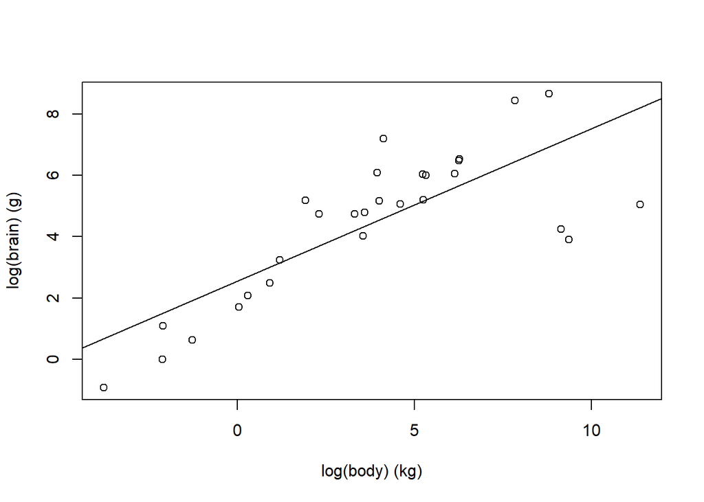

```r
plot(body, brain, xlab = "log(body) (kg)", ylab = "log(brain) (g)")
abline(model1)
```

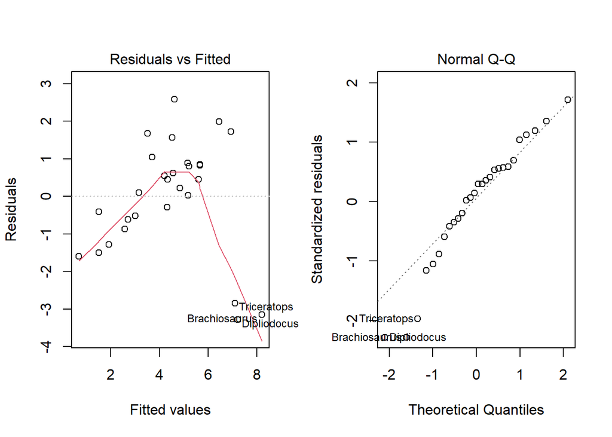

```r
par(mfrow = c(1, 2))
plot(model1, 1:2)
```

### 3d)

```r
AnimalsNoDinosaurs = Animals[-c(6, 16, 26),]
brain2 = log(AnimalsNoDinosaurs$brain)
body2 = log(AnimalsNoDinosaurs$body)
model2 = lm(brain2 ~ body2, data = log(AnimalsNoDinosaurs))

summary(model2)
```

```
##
## Call:
## lm(formula = brain2 ~ body2, data = log(AnimalsNoDinosaurs))
##
## Residuals:
##     Min      1Q  Median      3Q     Max
## -0.9125 -0.4752 -0.1557  0.1940  1.9303
##
## Coefficients:
##             Estimate Std. Error t value Pr(>|t|)
## (Intercept)  2.15041    0.20060   10.72 2.03e-10 ***
## body2        0.75226    0.04572   16.45 3.24e-14 ***
## ---
## Signif. codes:  0 '***' 0.001 '**' 0.01 '*' 0.05 '.' 0.1 ' ' 1
##
## Residual standard error: 0.7258 on 23 degrees of freedom
## Multiple R-squared:  0.9217, Adjusted R-squared:  0.9183
## F-statistic: 270.7 on 1 and 23 DF,  p-value: 3.243e-14
```

### 3e)

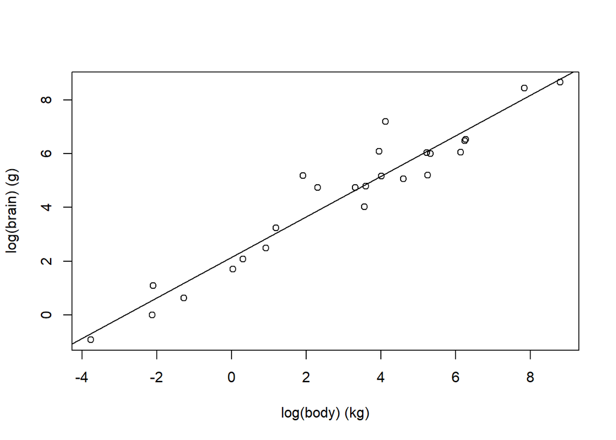

```r
plot(body2, brain2, xlab = "log(body) (kg)", ylab = "log(brain) (g)")
abline(model2)
```

### 3f)

```r
newdata = data.frame(body2 = 500)

predict(model2, newdata, interval = "confidence")
```

```
##        fit      lwr      upr
## 1 378.2808 331.2781 425.2834
```

## Question 5

### 5a)

H0: p1 = p2

H1: p1 ≠ p2

### 5b)

```r
x = c(120, 60)
n = c(800, 600)

p1 = prop.test(x, n)

p1
```

```
##
##  2-sample test for equality of proportions with continuity correction
##
## data:  x out of n
## X-squared = 7.2105, df = 1, p-value = 0.007248
## alternative hypothesis: two.sided
## 95 percent confidence interval:
##  0.01406774 0.08593226
## sample estimates:
## prop 1 prop 2
##   0.15   0.10
```

```r
z_statistic = sqrt(p1$statistic)

names(z_statistic) = NULL

cat('z_statistic:', z_statistic, '\n')
```

```
## z_statistic: 2.68524
```

```r
critical_value = qnorm(1-0.05/2)

cat('critical value:', critical_value, '\n')
```

```
## critical value: 1.959964
```

The observed value of the Z-statistic is 2.6852. When α = 0.05, the rejection region for this test is |z| > 1.96. Therefore we reject H0 and can conclude that there is evidence suggesting that the rates of babies with low birth weight differ between Africa and the Americas. More specifically, there is evidence that the rate is higher in Africa than the Americas.

### 5c)

```r
cat('z_statistic:', z_statistic, '\n')
```

```
## z_statistic: 2.68524
```

```r
critical_value = qnorm(1-0.01/2)

cat('critical value:', critical_value, '\n')
```

```
## critical value: 2.575829
```

If α = 0.01, then the rejection region for the test is |z| > 2.5758. Therefore we still reject H0 and conclude that there is evidence suggesting that the low birth weight rates differ between the two continents.

## 5d)

```r
conf_int = p1$conf.int

cat('95% confidence interval for difference in rates: (',round(conf_int[1], 4),',', round(conf_int[2], 4),')')
```

```
## 95% confidence interval for difference in rates: ( 0.0141 , 0.0859 )
```

### Question 6

## 6a)

```r
significance_level = pgeom(4, 0.4, lower.tail = FALSE) + dgeom(4, 0.4)
cat('The probability of committing a Type I Error is', significance_level)
```

```
## The probability of committing a Type I Error is 0.1296
```

## 6b)

```r
beta = pgeom(4, 0.2) - dgeom(4, 0.2)
cat('The probability of committing a Type II Error is', beta)
```

```
## The probability of committing a Type II Error is 0.5904
```

## 6c)

```r
K1 = function(p)
    1 - (pgeom(4, p) - dgeom(4, p))
p = seq(0, 0.4, 0.01)
K = K1(p)
```

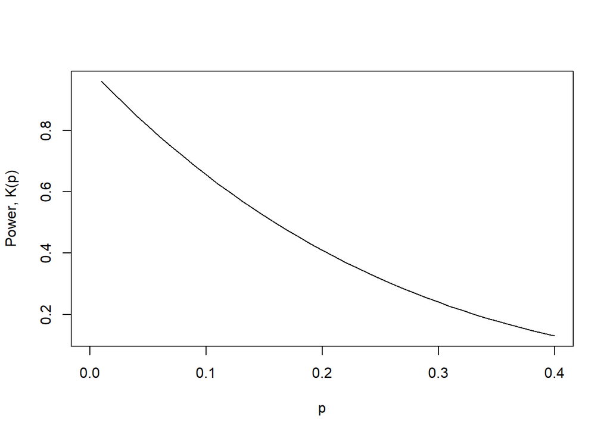

```r
plot(p, K, type = 'l', ylab = 'Power, K(p)')
```

## 6d)

```r
cat('significance level for critical value = 4:', pgeom(4, 0.4, lower.tail = FALSE) + dgeom(4, 0.4), '\n')
```

```
## significance level for critical value = 4: 0.1296
```

```r
cat('significance level for critical value = 5:', pgeom(5, 0.4, lower.tail = FALSE) + dgeom(5, 0.4), '\n')
```

```
## significance level for critical value = 5: 0.07776
```

```r
cat('significance level for critical value = 6:', pgeom(6, 0.4, lower.tail = FALSE) + dgeom(6, 0.4), '\n')
```

```
## significance level for critical value = 6: 0.046656
```

```r
cat('significance level for critical value = 7:', pgeom(7, 0.4, lower.tail = FALSE) + dgeom(7, 0.4), '\n')
```

```
## significance level for critical value = 7: 0.0279936
```

Therefore, a test where the null hypothesis is rejected if the observed value is greater than or equal to 6 gives an approximate significance level of 0.05. The actual significance level of this test is 0.046656.